# 203 Assignment 1

## Introduction

This assignment is going to use the principles of energy balance to examine how changing properties of urban environments alter the temperature of urban landscapes. In urban areas, the distribution of materials such as asphalt and concrete has been shown to lead to higher air temperatures compared to rural counterparts. This is known as the urban heat island (UHI) effect. High temperatures can be harmful to the health of residents, and in order to mitigate the UHI cities adopt strategies like increasing tree cover to increase shade and cooling, or increasing the reflectivity, also called albedo, with white paint. However, these strategies are not always evenly distributed throughout a city and may create environmental inequity. Read more about this phenomena [here](https://docs.google.com/document/d/1NUJATMo7KnmC3PpyFRdxo9HWH0F-zQxUDKiIW6pX7pY/edit#heading=h.z1slrwcvefnj).

We’ve assembled a dataset that captures a snapshot of average midday temperatures in August, the amount of vegetation, and a host of social/economic data across each neighborhood in the county of Los Angeles. The temperature data is from the Landsat satellite’s surface thermal data and was acquired in the Spring (April) and Summer (August) of 2020. The vegetation data is characterized by the Normalized Difference Vegetation Index (NDVI), and is taken from similar dates. [NDVI](https://earthobservatory.nasa.gov/features/MeasuringVegetation/measuring_vegetation_2.php) is a measure of “greenness” and higher values of NDVI indicate a greater amount of green vegetation within each neighborhood. The neighborhood information is collated from the incredibly awesome Mapping LA project developed by the [LA Times](http://maps.latimes.com/neighborhoods), which is worth checking out. See a description of each column in the dataset at this [link](https://docs.google.com/spreadsheets/d/1Hh-hMt5RuXA3lBYX8G16T3334zXQfbFnJzCxh3qbDsw/edit#gid=0)

**Note**: For those of you new to southern CA, August is the height of the Mediterranean dry season, and - in 2018 at least - it hasn’t rained much (if at all) since May. This means that the data on vegetation you are seeing must be associated with irrigated lawns, gardens, or parks and open spaces with numerous deeply-rooted trees.

### Part I: Exploring Los Angeles County Data

In this assignment, we’ll be exploring surface temperatures of different neighborhoods in Los Angeles County. To get a better idea of the spatial patterns within the county, check out the plot below. While the data we will use for analysis will be a finer spatial resolution, we include this just to give you a visual.

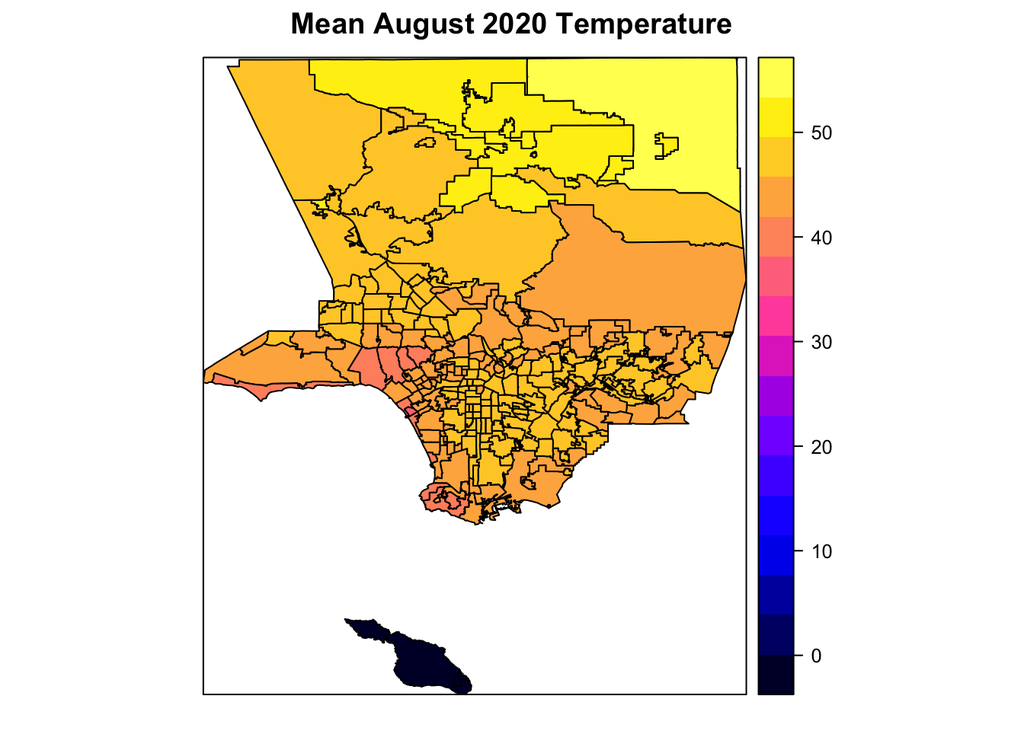

```r
# load shapefile - this contains map of neighborhoods
losang <- shapefile("ESM203_F2020_Ass1.shp")

# view spatially averaged temperature
spplot(losang, 'TEMP_SUMME', main="Mean August 2020 Temperature")
```

#### Observations

Lets start by just exploring our data. One of the first things we’d want to explore is what data is there. Run the code below to load the data and output the column names of all the data.

```r
# load in data as a CSV
LA_nbhds <- read.csv("ESM203_F2020_Ass1.csv")

# output column names
colnames(LA_nbhds)
```

```
##  [1] "NEIGHBORHOOD"        "POPULATION.PER.SQMI" "SINGLE.PARENTS"
##  [4] "ASIAN.POPULATION"    "LATINO.POPULATION"   "WHITE.POPULATION"
##  [7] "CRIME.PER.CAPITA"    "CRIME.TOTAL"         "DIVERSITY.INDEX"
## [10] "MEDIAN.INCOME"       "HOMEOWNERS"          "BLACK.POPULATION"
## [13] "NDVI_SPRING"         "NDVI_SUMMER"         "TEMP_SPRING"
## [16] "TEMP_SUMMER"
```

These column names tell us which variables are included in the data set.

Lets say you spent the evening playing around with the data looking for trends. Ideally we’d have a hypothesis in mind that we wanted to test, but sometimes in science you get lucky and stumble upon your hypothesis. So you were plotting variables (column names) against each other to see if there were any obvious correlations.

#### What are trends?

When we’re plotting data we’re looking for a relationship between two variables. Below are three different correlations we could expect. We have a positive correlation if Y increases with X , we have a negative correlation if Y decreases with X, and a seemingly randomly distribution of points indicates no correlation. At times correlations can be hard to detect so we will add a trend line and use statistics. [Here](https://infogram.com/blog/scatter-plots/) is a short description.

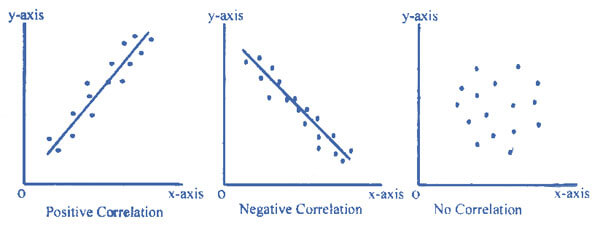

#### Summer NDVI v. surface temperatures

So in our exploration, one of the plots we made was mean August surface temperature against NDVI. We notice that this trend looks somewhat promising, and decide to plot a trend line. Do this by running the chunk below.

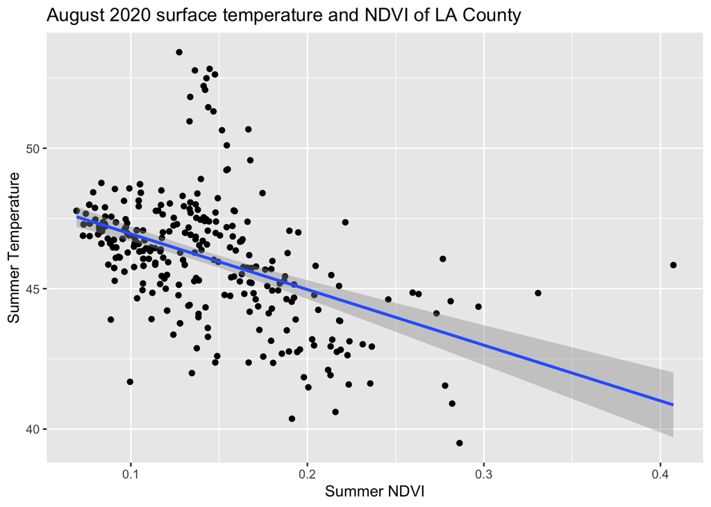

```r
LA_nbhds %>%
  dplyr::filter(NDVI_SUMMER > 0 & NDVI_SUMMER < 1) %>%
  ggplot() + geom_jitter(aes(x=NDVI_SUMMER, y=TEMP_SUMMER)) +
  geom_smooth(aes(x=NDVI_SUMMER, y=TEMP_SUMMER), method=lm) +
  labs(x = "Summer NDVI", y="Summer Temperature") +
  ggtitle("August 2020 surface temperature and NDVI of LA County")
```

##### Answer these questions:

1. Describe the relationship between temperature and NDVI

### Part II: Understanding the surface energy balance model

We’re gonna be using equations throughout this class, so lets learn how to become more literate in equations. To do this we’re going to explain the parameters in words as well as draw a conceptual model. This may take some time—but its an extremely important skill. So take a deep breath, be patient with yourself, and dive in.

Here is the somewhat simplified equation we will be using. You will first write a description of what each flux is.

$$Q_{av} = L_{out} + k_H(\Delta T) + k_E(\Delta VPD)$$

##### Answer these questions:

Define the terms of the equation. If you need a hint, check out this chapter on [surface energy fluxes](https://gauchospace.ucsb.edu/courses/pluginfile.php/10694510/mod_resource/content/2/Reading%20for%20Surface%20Energy%20Balance.pdf).

#### Draw a conceptual model

If you’re unsure about what a conceptual model is please reference the slides or Google it, and a hint – you’ve seen before the conceptual model you should be drawing.

### Part III: Solving for surface temperature

The chunk below consists of functions needed to do the assignment. No need to change or do anything here, just run this chunk so the equations can be used later.

```r
# the following functions are needed to solve the surface energy balance and calculate latent heat

# Tetens eq. to solve for saturated vapor pressure (used in LE eq.)
sat_vp <- function(T){
  e <- 0.61078*exp(17.27*T/(T+237.3))
  return(e)
}

# surface energy balance returns surface temperature
# input is surface temperature, represented as x (in celsius)
# veg represents % veg cover, alpha is albedo, and eps is emissivity
seb <- function(x, veg=0, alpha=0.15, eps=0.95){
  k_E = veg*50
  RH_s = veg
  L_inc = 0.9 * sigma * (T_a+273.15)^4  # W/m^2, incoming longwave radiation
Q_av = 0.9 * (K_inc*(1-alpha) + L_inc) # W/m^2
  k = Q_av
  L = eps*sigma*(x+273.15)^4
  Qh = k_H*(x-T_a)
  Qe = k_E*(RH_s*sat_vp(x) - RH*sat_vp(T_a))
  val = -k + L + Qh + Qe
  return(val)
}

## returns bar plot of the different fluxes
plot_fluxes <- function(veg){
  alpha=0.2
  range=c(1,100)
  x <- uniroot.all(seb, range, veg=veg, alpha=0.2)
  L_inc = 0.9 * sigma * (T_a+273.15)^4  # W/m^2, incoming   longwave radiation
  Q_av = 0.9 * (K_inc*(1-alpha) + L_inc) # W/m^2
  k = Q_av
  k_E = veg*50
  RH_s = veg
  L = 0.95*sigma*(x+273.15)^4
  Qh = k_H*(x-T_a)
  Qe = k_E*(RH_s*sat_vp(x) - RH*sat_vp(T_a))
  fluxes <- data.frame(flux=c("k","L","Qh","Qe"), value=c(k,L,Qh,Qe))
  plot <- ggplot(fluxes) + geom_col(aes(x=flux, y=value, fill=flux))
  return(plot)
}
```

In order to use this equation to test our hypothesis we are going to do a sensitivity analysis. To perform this, we vary one parameter at a time and observe how the output changes, which in this case the output we care about is temperature. We’re first going to do an example together, and then you’ll do one on your own.

#### Albedo

We learned in class that albedo affects the amount of shortwave radiation entering the surface by reflecting some back. Albedo affects the available energy at the surface, $Q_{av}$ through the equations:

$$K_{net} = (K_{inc}*(1-\alpha)$$

Where $\alpha$ represents albedo. Use the code below to explore the model outcomes, and to answer the questions below.

The follow chunk includes variables that are inputs for the model. No need to change these.

```r
T_a = 28 # ambient atm temp in Celsius
sigma = 5.6704*10^-8 #W/m^2/K^4 stefan-boltzmann constant
k_H = 21 # Sensible heat conductivity [J/deg-C]
#k_E = 100 # [J/kPa] Latent heat conductivity (only present if surface is wet)
RH = 0.4 # Relative humidity of atmosphere, [0-1]
K_inc = 800 # W/m^2, incoming shortwave radiation
```

```r
## Run the below code to solve for surface temperature
# temp_s is surface temperature
range = c(0,100)
test_albedo <- function(x){
  temp_s = uniroot.all(seb, range, alpha=x)
  return(temp_s)
}

# You can solve for surface temp by inputting specific values of albedo, where x is albedo - replace 0.9 with any value between 0 and 1.
test_albedo(x=0.9)
```

```
## [1] 28.24953
```

```r
# The code below runs the above function for every value of albedo in the 'alpha' vector below
# quick sensitivity analysis for veg parameter
# alpha <- seq(0,1, by=0.05)
# test <- sapply(X=alpha, FUN=test_albedo)
# plot albedo v. temp
# plot(alpha, test, xlab="Albedo", ylab="Surface temperature")
```

##### Answer these questions:

10. What happens to the surface temperature when albedo increases?

#### Vegetation

Now its your turn do a sensitivity analysis based upon the amount of vegetation.

Remember that we defined latent energy as:

$$Q_E = k_E(\Delta VPD)$$

But in reality, it’s a bit more complicated:

$$Q_E = -\frac{\rho*C_p}{\gamma}*\frac{e_a - e_{*}[T_s]}{r}$$

Where $-\frac{\rho*C_p}{\gamma}$ represents the density of water, specific heat capacity, and the psychometric constant. The second part, $(e_a - e_{*}[T_s])$ is the vapor pressure deficit, or the difference between the saturated surface and the air. The amount of saturation of a **vegetated** surface depends on how much water is available to the vegetation. $r$ in the equation represents a resistance, that can change with vegetation ecophysiological differences and atmospheric conditions. We will be learning more about this later in 203. For now, we created a dummy variable, called ‘veg’, that accounts for these changes when vegetation is present.

In the same way we did a sensitivity analysis for albedo, this chunk does a sensitivity analysis for vegetation.

```r
## Run the below code to solve for surface temperature
# temp_s is surface temperature
range = c(0,100)
test_veg <- function(veg){
  temp_s = uniroot.all(seb, range, veg=veg)
  return(temp_s)
}

# do a sensitivity analysis for the veg parameter by copying the code from above, but instead of test_albedo, use test_veg. Add this below
```

We have created a function that lets you plot the different energy fluxes based on the amount of vegetation. Use this tool to help conceptualize the results of your sensitivity analysis above. You can change the number in plot_fluxes(veg=#) to see how different amounts of vegetation affect the different major fluxes of the energy model. If it helps, copy and past the chunk to plot multiples of these.

```r
# plot_fluxes() shows a bar plot of the different energy fluxes. Change veg between 0 to 1 to see how the latent and sensible energy change
# run the function plot_fluxes in the lines below
```

##### Answer these questions:

13. How does the presence of vegetation affect the surface temperature?

### Part IV: Connecting to socioeconomic data

Remember the NDVI. v. temp plot above? Now it’s your turn to explore the data set (LA_nbhds) and create your own plots. This is your turn to apply what you have learned and get creative. You can use anything you’ve learned from 206 so far to explore and summarize the data. Create at least one plot that includes NDVI or temperature on the x-axis, and a socio-economic variable on the y-axis. You can copy and paste the code from above, but also be creative! Then answer the reflection questions below.

```r
## plot here
```

16. Based on your plot(s) what relationship exists? Write a short (1-2 paragraph max) reaction/response to your findings, focusing on what they imply for issues related to environmental management, planning, and/or environmental justice. While your response should refer to the specifics of your plots/presentation, you do not need to do an exhaustive analysis or find citations to support your inference.